written by ideajoon  
※ 참고 : 딥 러닝을 이용한 자연어 처리 입문 (https://wikidocs.net/book/2155) 자료를 공부하고 정리함

# 11. 태깅 작업(Tagging Task)

각 단어가 어떤 유형에 속해있는지를 알아내는 태깅 작업

- 개체명 인식(Named Entity Recognition)  
  각 단어의 유형이 사람, 장소, 단체 등 어떤 유형인지를 알아내는 작업
- 품사 태깅(Part-of-Speech Tagging)  
  각 단어의 품사가 명사, 동사, 형용사 인지를 알아내는 작업

## 목차

1. 케라스를 이용한 태깅 작업 개요(Tagging Task using Keras)
2. 개체명 인식(Named Entity Recognition)
3. 양방향 LSTM을 이용한 개체명 인식(Named Entity Recognition using Bi-LSTM)
4. 양방향 LSTM을 이용한 품사 태깅(Part-of-speech Tagging using Bi-LSTM)
5. 양방향 LSTM과 CRF(Bidirectional LSTM + CRF)

## 1. 케라스를 이용한 태깅 작업 개요(Tagging Task using Keras)

케라스(Keras)로 인공 신경망을 이용하여 태깅 작업을 하는 모델을 만듭니다. 즉, 개체명 인식기와 품사 태거를 만든다. 이러한 두 작업의 공통점은 RNN의 다-대-다(Many-to-Many) 작업이면서 또한 앞, 뒤 시점의 입력을 모두 참고하는 양방향 RNN(Bidirectional RNN)을 사용한다는 점입니다.

### 1) 훈련 데이터에 대한 이해

태깅 작업은 앞서 배운 텍스트 분류 작업과 동일하게 지도 학습(Supervised Learning)에 속합니다.

| 구분 | X_train | y_train | 길이 |
| --- | --- | --- | --- |
| 0 | ['EU', 'rejects', 'German', 'call', 'to', 'boycott', 'British', 'lamb'] | ['B-ORG', 'O', 'B-MISC', 'O', 'O', 'O', 'B-MISC', 'O'] | 8 |
| 1 | ['peter', 'blackburn'] | ['B-PER', 'I-PER'] | 2 |
| 2 | ['brussels', '1996-08-22' ] | ['B-LOC', 'O'] | 2 |
| 3 | ['The', 'European', 'Commission'] | ['O', 'B-ORG', 'I-ORG'] | 3 |

이렇게 병렬 관계를 가지는 각 데이터는 정수 인코딩 과정을 거친 후, 모든 데이터의 길이를 동일하게 맞춰주기위한 패딩(Padding) 작업을 거칩니다.

### 2) 시퀀스 레이블링(Sequence Labeling)

위와 같이 입력 시퀀스 X = [x1, x2, x3, ..., xn]에 대하여 레이블 시퀀스 y = [y1, y2, y3, ..., yn]를 각각 부여하는 작업을 시퀀스 레이블링 작업(Sequence Labeling Task)이라고 합니다.

### 3) 양방향 LSTM(Bidirectional LSTM)

```
model.add(Bidirectional(LSTM(hidden_size, return_sequences=True)))
```

양방향 LSTM을 사용합니다. 양방향은 기존의 단방향 LSTM()을 Bidirectional() 안에 넣으면 됩니다.

인자 정보는 단방향 LSTM을 사용할 때와 동일합니다. 즉, 인자값을 하나를 줄 경우에는 이는 hidden_size를 의미하며, 결과적으로 output_dim이 됩니다.

### 4) RNN의 다-대-다(Many-to-Many) 문제

[figure not shown]

- return_sequences=True  
  RNN의 다-대-다(Many-to-Many)로 설정한다.
- return_sequences=False  
  RNN의 다-대-일(Many-to-One)로 설정한다.

예를 들어 위에서 설명한 데이터 중 첫번째 데이터에 해당되는 X_train[0]를 가지고 4번의 시점(timesteps)까지 RNN을 진행하였을 때의 그림은 다음과 같습니다.

[figure not shown]

하지만 이번 실습에서는 양방향 RNN을 사용할 것이므로 아래의 그림과 같습니다.

[figure not shown]

## 2. 개체명 인식(Named Entity Recognition)

### 1) 개체명 인식(Named Entity Recognition)이란?

- 도연 - 사람
- 2018년 - 시간
- 골드만삭스 - 조직

개체명 모델이 토큰화와 품사 태깅(POS Tagging, Part-Of-Speech Tagging) 전처리를 끝내고 난 상태를 입력으로 요구하기도 합니다.

### 2) NLTK를 이용한 개체명 인식(Named Entity Recognition using NTLK)

NLTK에서는 개체명 인식기(NER chunker)를 지원한다.

```python
from nltk import word_tokenize, pos_tag, ne_chunk
sentence = "James is working at Disney in London"
sentence=pos_tag(word_tokenize(sentence))
print(sentence) # 토큰화와 품사 태깅을 동시 수행
```

```
[('James', 'NNP'), ('is', 'VBZ'), ('working', 'VBG'), ('at', 'IN'), ('Disney', 'NNP'), ('in', 'IN'), ('London', 'NNP')]
```

```python
sentence=ne_chunk(sentence)
print(sentence) # 개체명 인식
```

```
(S
  (PERSON James/NNP)
  is/VBZ
  working/VBG
  at/IN
  (ORGANIZATION Disney/NNP)
  in/IN
  (GPE London/NNP))
```

ne_chunk는 개체명을 태깅하기 위해서 앞서 품사 태깅(pos_tag)이 수행되어야 합니다. 위의 결과에서 James는 PERSON(사람), Disney는 조직(ORGANIZATION), London은 위치(GPE)라고 정상적으로 개체명 인식이 수행된 것을 볼 수 있습니다.

## 3. 양방향 LSTM을 이용한 개체명 인식(Named Entity Recognition using Bi-LSTM)

### 1) BIO 표현

B는 Begin의 약자로 개체명이 시작되는 부분, I는 Inside의 약자로 개체명의 내부 부분을 의미하며, O는 Outside의 약자로 개체명이 아닌 부분을 의미합니다.

예를 들어서 영화에 대한 코퍼스 중에서 영화 제목에 대한 개체명을 뽑아내고 싶다고 가정합시다.

해 B  
리 I  
포 I  
터 I  
보 O  
러 O  
가 O  
자 O

영화 제목이 시작되는 글자인 '해'에서는 B가 사용되었고, 그리고 영화 제목이 끝나는 순간까지 I가 사용됩니다. 그리고 영화 제목이 아닌 부분에 대해서만 O가 사용됩니다.

영화 제목에 대한 개체명과 극장에 대한 개체명이 있을 수 있습니다. 그럴 때는, 각 개체가 어떤 종류인지도 함께 태깅이 될 것입니다.

해 B-movie  
리 I-movie  
포 I-movie  
터 I-movie  
보 O  
러 O  
메 B-theater  
가 I-theater  
박 I-theater  
스 I-theater  
가 O  
자 O

### 2) 양방향 LSTM(Bi-directional LSTM)으로 개체명 인식기 만들기

CONLL2003은 개체명 인식을 위한 전통적인 영어 데이터 셋입니다.

다운로드 링크 : https://raw.githubusercontent.com/Franck-Dernoncourt/NeuroNER/master/neuroner/data/conll2003/en/train.txt  
전체 데이터는 위 링크에서 train.txt 파일을 다운로드 받을 수 있습니다.

해당 데이터의 양식은 [단어] [품사 태깅] [청크 태깅] [개체명 태깅]의 형식으로 되어있습니다.

품사 태깅이 의미하는 바는 아래 링크 확인  
https://www.ling.upenn.edu/courses/Fall_2003/ling001/penn_treebank_pos.html

EU NNP B-NP B-ORG  
rejects VBZ B-VP O  
German JJ B-NP B-MISC  
call NN I-NP O  
to TO B-VP O  
boycott VB I-VP O  
British JJ B-NP B-MISC  
lamb NN I-NP O  
. . O O

Peter NNP B-NP B-PER  
Blackburn NNP I-NP I-PER

예를 들어서 EU 옆에 붙어있는 NNP는 고유 명사 단수형을 의미하며, rejects 옆에 있는 VBZ는 3인칭 단수 동사 현재형을 의미합니다.

개체명 태깅의 경우에는 LOC는 location, ORG는 organization, PER은 person, MISC는 miscellaneous를 의미합니다.

다만, German 그 자체로 개체명 하나이기 때문에 거기서 개체명 인식은 종료되면서 뒤에 I가 별도로 붙는 단어가 나오지는 않았습니다.

call은 개체명이 아니기 때문에 O가 태깅이 됩니다.

10번째 줄은 공란으로 되어 있는데, 이는 9번째 줄에서 문장이 끝나고 11번째 줄에서 새로운 문장이 시작됨을 의미합니다.

Peter는 개체명이 시작되면서 person에 해당되기 때문에 B-PER이라는 개체명 태깅이 붙습니다.

Blackburn에서는 I가 나오면서 I-PER이 개체명 태깅으로 붙게 됩니다.

```python
from collections import Counter
vocab=Counter()
import re
```

우선 훈련 데이터의 단어의 빈도수를 세기위해서 Counter, 데이터를 정제하기 위해서 re가 필요합니다.

```python
f = open('train.txt', 'r')
sentences = []
sentence = []
ner_set = set()
# 파이썬의 set은 중복을 허용하지 않는다. 개체명 태깅의 경우의 수. 즉, 종류를 알아내기 위함이다.

for line in f:
    if len(line)==0 or line.startswith('-DOCSTART') or line[0]=="\n":
        if len(sentence) > 0:
            sentences.append(sentence)
            sentence=[]
        continue
    splits = line.split(' ')
    # 공백을 기준으로 속성을 구분한다.
    splits[-1] = re.sub(r'\n', '', splits[-1])
    # 개체명 태깅 뒤에 붙어있는 줄바꿈 표시 \n을 제거한다.
    word=splits[0].lower()
    # 단어들은 소문자로 바꿔서 저장한다. 단어의 수를 줄이기 위해서이다.
    vocab[word]=vocab[word]+1
    # 단어마다 빈도 수가 몇 인지 기록한다.
    sentence.append([word, splits[-1]])
    # 단어와 개체명 태깅만 기록한다.
    ner_set.add(splits[-1])
    # set에다가 개체명 태깅을 집어 넣는다. 중복은 허용되지 않으므로
    # 나중에 개체명 태깅이 어떤 종류가 있는지 확인할 수 있다.
```

위의 코드를 거치면 단어와 개체명 태깅만이 남게되며, 문장의 구분이 유지됩니다.

```python
sentences[:3]
```

```
[[['eu', 'B-ORG'],
  ['rejects', 'O'],
  ['german', 'B-MISC'],
  ['call', 'O'],
  ['to', 'O'],
  ['boycott', 'O'],
  ['british', 'B-MISC'],
  ['lamb', 'O'],
  ['.', 'O']],
 [['peter', 'B-PER'], ['blackburn', 'I-PER']],
 [['brussels', 'B-LOC'], ['1996-08-22', 'O']]]
```

위의 코드 중 'vocab[word]=vocab[word]+1' 해당 부분을 통해 현재 vocab은 각 단어에 대한 빈도수가 기록되어 있는 단어 집합이 되었습니다.

한 번 vocab에 저장된 데이터를 확인해보도록 하겠습니다.

```python
vocab
```

```
Counter({'eu': 24,
         'rejects': 1,
         'german': 101,
         'call': 38,
         'to': 3424,
         'boycott': 5,
         'british': 96,
         'lamb': 3,
         '.': 7374,
         'peter': 31,
         'blackburn': 12,
         'brussels': 33,
         '1996-08-22': 125,
         'the': 8390,
         'european': 94,
         'commission': 67,
         'said': 1849,
         'on': 2092,
         'thursday': 292,
         'it': 762,
         'disagreed': 2,
         'with': 867,
         'advice': 5,
         'consumers': 9,
         'shun': 1,
         'until': 56,
         'scientists': 6,
         'determine': 11,
         'whether': 45,
         'mad': 13,
         'cow': 12,
         'disease': 37,
         'can': 72,
         'be': 525,
         'transmitted': 2,
         'sheep': 14,
         'germany': 144,
         "'s": 1566,
         'representative': 7,
         'union': 74,
```

[output cut: 946 more lines]

```
         '3/8': 1,
         'three': 214,
         'months': 60,
         '5-5/8': 1,
         '1/2': 84,
         'six': 127,
         '5-3/4': 1,
         '5/8': 5,
         'one-year': 1,
         'funds': 13,
         '5-7/8': 1,
         'approves': 3,
         'arafat': 47,
         'flight': 26,
         ...})
```

vocab이 위와 같은 데이터의 형식을 갖고 있기 때문에, vocab의 길이를 측정하면 단어의 개수를 알수 있습니다.

```python
len(vocab)
```

```
21009
```

훈련 데이터에는 약 21,000여개의 단어가 있음을 알 수 있습니다.

앞서 개체명 태깅의 종류를 알기 위해서 ner_set에다가 중복은 허용하지 않고, 개체명 태깅을 저장했습니다.

```python
print(ner_set)
```

```
{'B-ORG', 'I-MISC', 'I-LOC', 'I-PER', 'B-LOC', 'O', 'B-PER', 'I-ORG', 'B-MISC'}
```

훈련 데이터에 등장하는 개체명 태깅의 수는 위와 같습니다.

이제 vocab 안의 단어들을 빈도수 순으로 정렬해보도록 하겠습니다.

```python
vocab_sorted=sorted(vocab.items(), key=lambda x:x[1], reverse=True)
# vocab을 빈도수 순으로 정렬한다.
vocab_sorted
# 출력
```

```
[('the', 8390),
 ('.', 7374),
 (',', 7290),
 ('of', 3815),
 ('in', 3621),
 ('to', 3424),
 ('a', 3199),
 ('and', 2872),
 ('(', 2861),
 (')', 2861),
 ('"', 2178),
 ('on', 2092),
 ('said', 1849),
 ("'s", 1566),
 ('for', 1465),
 ('1', 1421),
 ('-', 1243),
 ('at', 1146),
 ('was', 1095),
 ('2', 973),
 ('0', 945),
 ('3', 932),
 ('with', 867),
 ('that', 797),
 ('he', 792),
 ('from', 768),
 ('it', 762),
 ('by', 726),
 ('is', 694),
 (':', 691),
 ('as', 630),
 ('4', 581),
 ('had', 561),
 ('his', 559),
 ('has', 559),
 ('but', 545),
 ('an', 542),
 ('not', 541),
 ('were', 531),
 ('be', 525),
```

[output cut: 946 more lines]

```
 ('lot', 25),
 ('eu', 24),
 ('needed', 24),
 ('similar', 24),
 ('denied', 24),
 ('paper', 24),
 ('beijing', 24),
 ('province', 24),
 ('executive', 24),
 ('compared', 24),
 ('300', 24),
 ('schedule', 24),
 ('firm', 24),
 ('digest', 24),
 ...]
```

사실 해당 데이터는 등장 빈도가 1인 데이터도 다수입니다. 전체 데이터에서 단어의 등장 빈도수가 5이하인 경우는 데이터에서 배제시키고, 모르는 단어. OOV(Out-of-Vocabulary)로 간주합니다. 여기서 vocab_sorted 부분에서 굳이 빈도수가 5이하인 경우를 빼서 저장하지 않고 vocab_sorted로 부터 또 다시 새로운 단어 집합을 만듭니다.

이번에 만드는 단어 집합은 등장 빈도수 순으로 인덱스를 부여합니다. 그리고 이 때, 빈도수가 5이하인 단어들을 배제시킵니다.

```python
word_to_index = {w: i + 2 for i, (w, n) in enumerate(vocab_sorted) if n > 5}
word_to_index['PAD'] = 0  # 패딩을 위해 인덱스 0 할당
word_to_index['OOV'] = 1  # 모르는 단어을 위해 인덱스 1 할당
word_to_index # 출력
```

```
{'the': 2,
 '.': 3,
 ',': 4,
 'of': 5,
 'in': 6,
 'to': 7,
 'a': 8,
 'and': 9,
 '(': 10,
 ')': 11,
 '"': 12,
 'on': 13,
 'said': 14,
 "'s": 15,
 'for': 16,
 '1': 17,
 '-': 18,
 'at': 19,
 'was': 20,
 '2': 21,
 '0': 22,
 '3': 23,
 'with': 24,
 'that': 25,
 'he': 26,
 'from': 27,
 'it': 28,
 'by': 29,
 'is': 30,
 ':': 31,
 'as': 32,
 '4': 33,
 'had': 34,
 'his': 35,
 'has': 36,
 'but': 37,
 'an': 38,
 'not': 39,
 'were': 40,
 'be': 41,
```

[output cut: 946 more lines]

```
 'lot': 988,
 'eu': 989,
 'needed': 990,
 'similar': 991,
 'denied': 992,
 'paper': 993,
 'beijing': 994,
 'province': 995,
 'executive': 996,
 'compared': 997,
 '300': 998,
 'schedule': 999,
 'firm': 1000,
 'digest': 1001,
 ...}
```

향후 훈련 데이터의 길이를 모두 맞추기위해 인덱스 0에는 'PAD'라는 단어를 넣고, 인덱스 1에는 단어 집합에 없는 단어들을 별도로 표시하기 위한 'OOV'라는 단어를 부여합니다.

해당 단어 집합은 단어의 등장 빈도 순위에 따라서 인덱스를 부여합니다. word_to_index의 인덱스 0에 'PAD'와 인덱스 1에 'OOV'도 추가된 상태입니다. 인덱스 2부터는 등장 빈도수가 가장 높은 단어 순서대로 부여되는데, 등장 빈도수가 가장 높은 the의 경우에는 인덱스 2에 할당됩니다.

해당 단어 집합의 크기를 확인해보겠습니다.

```python
print(len(word_to_index))
```

```
3939
```

약 21,000개에 달했던 단어 집합이 빈도수 5이하인 단어들을 배제시키자, 3939개의 단어만을 가진 단어 집합으로 단어의 개수가 대폭 줄어든 것을 확인할 수 있습니다.

이제 word_to_index를 통해 단어를 입력하면, 인덱스를 리턴받을 수 있습니다.

```python
word_to_index['the']
```

```
2
```

입력받은 개체명 태깅에 대해서 인덱스를 리턴하는 ner_to_index를 만들어보도록 하겠습니다.

```python
ner_to_index={}
ner_to_index['PAD'] = 0
i=1
for ner in ner_set:
    ner_to_index[ner]=i
    i=i+1
print(ner_to_index)
```

```
{'PAD': 0, 'B-ORG': 1, 'I-MISC': 2, 'I-LOC': 3, 'I-PER': 4, 'B-LOC': 5, 'O': 6, 'B-PER': 7, 'I-ORG': 8, 'B-MISC': 9}
```

이제 ner_to_index에다가 개체명 태깅을 입력하면 인덱스를 리턴받을 수 있습니다.

```python
ner_to_index['I-PER']
```

```
4
```

이제 훈련 데이터를 정수 인코딩할 준비가 끝났습니다.

이제 모든 훈련 데이터를 담고 있는 sentences로 부터 word_to_index와 ner_to_index를 통해 모든 훈련 데이터를 숫자로 바꿉니다.

우선 word_to_index를 사용하여 단어에 대해서 훈련 데이터인 data_X를 만듭니다.

```python
data_X = []

for s in sentences:
    temp_X = []
    for w, label in s:
        try:
            temp_X.append(word_to_index.get(w,1))
        except KeyError:
            temp_X.append(word_to_index['OOV'])

    data_X.append(temp_X)
print(data_X[:10])
```

```
[[989, 1, 205, 629, 7, 1, 216, 1, 3], [774, 1872], [726, 150], [2, 219, 334, 14, 13, 70, 28, 1, 24, 205, 1, 7, 2404, 7, 1, 216, 1, 406, 3382, 2009, 519, 1745, 1873, 648, 309, 41, 1, 7, 1632, 3], [124, 15, 2991, 7, 2, 219, 300, 15, 2660, 801, 1, 1, 14, 13, 75, 2404, 276, 914, 1, 27, 539, 127, 125, 13…
```

정상적으로 변환이 되었는지 보기 위해서 첫번째 샘플에 대해서만 기존의 단어 시퀀스를 출력해보겠습니다.

```python
index_to_word={}
for key, value in word_to_index.items(): # 인덱스를 단어로 바꾸기 위해 index_to_word를 생성
    index_to_word[value] = key


temp = []
for index in data_X[0] : # 첫번째 샘플 안의 인덱스들에 대해서
    temp.append(index_to_word[index]) # 다시 단어로 변환

print(sentences[0])
print(temp)
```

```
[['eu', 'B-ORG'], ['rejects', 'O'], ['german', 'B-MISC'], ['call', 'O'], ['to', 'O'], ['boycott', 'O'], ['british', 'B-MISC'], ['lamb', 'O'], ['.', 'O']]
['eu', 'OOV', 'german', 'call', 'to', 'OOV', 'british', 'OOV', '.']
```

rejects와 boycott, lamb는 사라지고 'OOV'로 바뀌었는데, 이는 앞에서 빈도수가 5 이하인 단어들에 대해서는 단어 집합에 해당되는 word_to_index에 저장시키지 않았고 이에 따라 모르는 단어 'OOV'로 간주되었기 때문입니다.

이제 모든 훈련 데이터를 담고 있는 sentences에서 개체명 태깅에 해당되는 부분을 모아 data_y에 저장하는 작업을 수행해보도록 하겠습니다.

```python
data_y = []

for s in sentences:
    temp_y = []
    for w, label in s:
            temp_y.append(ner_to_index.get(label))

    data_y.append(temp_y)
```

```python
print(data_X[:4]) # X 데이터 4개만 출력
print(data_y[:4]) # y 데이터 4개만 출력
```

```
[[989, 1, 205, 629, 7, 1, 216, 1, 3], [774, 1872], [726, 150], [2, 219, 334, 14, 13, 70, 28, 1, 24, 205, 1, 7, 2404, 7, 1, 216, 1, 406, 3382, 2009, 519, 1745, 1873, 648, 309, 41, 1, 7, 1632, 3]]
[[1, 6, 9, 6, 6, 6, 9, 6, 6], [7, 4], [5, 6], [6, 1, 8, 6, 6, 6, 6, 6, 6, 9, 6, 6, 6, 6, 6, 9, 6, 6, 6, 6, 6, 6, 6, 6, 6, 6, 6, 6, 6, 6]]
```

이제 단어에 대한 훈련 데이터인 data_X와 개체명 태깅에 대한 훈련 데이터인 data_y가 만들어졌습니다.

그런데 data_X의 단어 시퀀스 데이터 각각과 data_y 단어 시퀀스 데이터 각각은 전부 길이가 천차만별입니다.

각 샘플의 길이가 대체적으로 어떻게 되는지 시각화해보도록 하겠습니다.

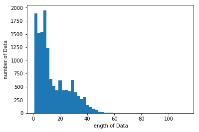

```python
%matplotlib inline
import matplotlib.pyplot as plt

plt.hist([len(s) for s in data_X], bins=50)
plt.xlabel('length of Data')
plt.ylabel('number of Data')
plt.show()
```

위의 그래프는 샘플들의 길이가 대체적으로 0~40의 길이를 가지며, 특히 0~20의 길이를 가진 샘플이 상당한 비율을 차지하는 것을 보여줍니다.

양방향 LSTM 모델에 손쉽게 데이터를 입력으로 사용하기 위해서, 여기서는 모든 샘플의 길이를 동일하게 맞추도록 하겠습니다.

가장 길이가 긴 샘플의 길이를 우선 구해보도록 하겠습니다.

```python
print(max(len(l) for l in data_X)) # 전체 데이터에서 길이가 가장 긴 샘플의 길이 출력
print(max(len(l) for l in data_y)) # 전체 데이터에서 길이가 가장 긴 샘플의 길이 출력
```

```
113
113
```

```python
max_len=70
from keras.preprocessing.sequence import pad_sequences
pad_X = pad_sequences(data_X, padding='post', maxlen=max_len)
# data_X의 모든 샘플들의 길이를 맞출 때 뒤의 공간에 숫자 0으로 채움.
pad_y = pad_sequences(data_y, padding='post', maxlen=max_len)
# data_y의 모든 샘플들의 길이를 맞출 때 뒤의 공간에 숫자0으로 채움.
```

data_X와 data_y의 전체 데이터에서 길이가 70보다 작은 샘플들은 길이를 맞추기 위해 남는 공간에 숫자 0이 들어갑니다. 숫자 0은 앞서 단어 집합 word_to_index와 ner_to_index에서 임의로 패딩을 위해 만들어준 단어 'PAD'에 해당됩니다.

```python
print(min(len(l) for l in pad_X)) # 모든 데이터에서 길이가 가장 짧은 샘플의 길이 출력
print(min(len(l) for l in pad_y)) # 모든 데이터에서 길이가 가장 짧은 샘플의 길이 출력
```

```
70
70
```

pad_X와 pad_y를 훈련 데이터와 테스트 데이터로 8:2로 분할합니다.

```python
from sklearn.model_selection import train_test_split
X_train, X_test, y_train, y_test = train_test_split(pad_X, pad_y, test_size=.2, random_state=777)
```

random_state를 지정했기 때문에 기존의 pad_X와 pad_y에서 순서가 섞이면서 훈련 데이터와 테스트 데이터로 분할됩니다. 즉, 이제 X_train의 첫번째 샘플과 pad_X에서의 첫번째 샘플은 서로 다른 샘플일 수 있습니다.

```python
print(len(X_train), len(X_test), len(y_train), len(y_test))
```

```
11232 2809 11232 2809
```

```python
from keras.models import Sequential
from keras.layers import Dense, Embedding, LSTM, Bidirectional, TimeDistributed
from keras.optimizers import Adam
```

모델 설계를 하겠습니다.

```python
n_words = len(word_to_index)
n_labels = len(ner_to_index)
```

```python
model = Sequential()
model.add(Embedding(input_dim=n_words, output_dim=16, input_length=max_len, mask_zero=True))
model.add(Bidirectional(LSTM(32, return_sequences=True)))
model.add(TimeDistributed(Dense(n_labels, activation='softmax')))
```

Many-to-Many 문제이므로 LSTM()에 return_sequences=True를 설정해준 것을 볼 수 있습니다.

이번 실습과 같이 각 데이터의 길이가 달라서 패딩을 하느라 숫자 0이 많아질 경우에는 Embedding()에 mask_zero=True를 설정하여 데이터에서 숫자 0은 패딩을 의미하므로 연산에서 제외시킨다는 옵션을 줄 수 있습니다.

```python
model.compile(loss='categorical_crossentropy', optimizer=Adam(0.001), metrics=['accuracy'])
```

훈련 데이터에 대해서 원-핫 인코딩을 진행합니다.

```python
from keras.utils import np_utils
y_train2 = np_utils.to_categorical(y_train)
y_train2[0][0]
```

```
array([0., 1., 0., 0., 0., 0., 0., 0., 0., 0.], dtype=float32)
```

```python
model.fit(X_train, y_train2, epochs=2) #원래는 예제에서 epochs=8 이지만 시간단축을 위해 epochs=2로 설정
```

```
<keras.callbacks.History at 0x1c2bfa21be0>
```

```python
y_test2 = np_utils.to_categorical(y_test)
print("\n 테스트 정확도: %.4f" % (model.evaluate(X_test, y_test2)[1]))
```

```
 테스트 정확도: 0.8771
```

실제로 맞추고 있는지를 테스트 데이터를 주고 직접 실제값과 비교해보도록 하겠습니다.

```python
import numpy as np

index_to_word={}
for key, value in word_to_index.items():
    index_to_word[value] = key

index_to_ner={}
for key, value in ner_to_index.items():
    index_to_ner[value] = key


i=10 # 확인하고 싶은 테스트용 샘플의 인덱스.
y_predicted = model.predict(np.array([X_test[i]])) # 입력한 테스트용 샘플에 대해서 예측 y를 리턴
y_predicted = np.argmax(y_predicted, axis=-1) # 원-핫 인코딩을 다시 정수 인코딩으로 변경함.
true = np.argmax(y_test2[i], -1) # 원-핫 인코딩을 다시 정수 인코딩으로 변경함.

print("{:15}|{:5}|{}".format("단어", "실제값", "예측값"))
print(35 * "-")

for w, t, pred in zip(X_test[i], true, y_predicted[0]):
    if w != 0: # PAD값은 제외함.
        print("{:17}: {:7} {}".format(index_to_word[w], index_to_ner[t], index_to_ner[pred]))
```

```
단어             |실제값  |예측값
-----------------------------------
sarah            : B-PER   B-PER
brady            : I-PER   B-LOC
,                : O       O
whose            : O       O
republican       : B-MISC  B-LOC
husband          : O       O
was              : O       O
OOV              : O       O
OOV              : O       O
in               : O       O
an               : O       O
OOV              : O       O
attempt          : O       O
on               : O       O
president        : O       O
ronald           : B-PER   B-LOC
reagan           : I-PER   I-ORG
,                : O       O
took             : O       O
centre           : O       O
stage            : O       O
at               : O       O
the              : O       O
democratic       : B-MISC  B-LOC
national         : I-MISC  I-ORG
convention       : I-MISC  O
on               : O       O
monday           : O       O
night            : O       O
to               : O       O
OOV              : O       O
president        : O       O
bill             : B-PER   O
clinton          : I-PER   I-PER
's               : O       O
gun              : O       O
control          : O       O
efforts          : O       O
.                : O       O
```

위의 결과는 정확도가 높지 않지만 epochs = 8로 한다면 정확도 높은 결과를 볼 수 있다.

하지만 출력 결과는 그럴듯해 보이지만 사실 이번에 사용한 정확도 측정 방법이 그다지 적절하지는 않았습니다.

그 이유에 대해서는 뒤에서 나오는 양방향 LSTM과 CRF에서 찾을 수 있다.

## 4. 양방향 LSTM을 이용한 품사 태깅(Part-of-speech Tagging using Bi-LSTM)

직접 양방향 LSTM을 이용한 품사 태깅을 수행하는 모델을 만들기

### 1) 양방향 LSTM(Bi-directional LSTM)으로 POS Tagger 만들기

NLTK를 이용하면 영어 코퍼스에 토큰화와 품사 태깅 전처리를 진행한 총 3,914개의 문장 데이터를 받아올 수 있습니다.

```python
import nltk
tagged_sentences = nltk.corpus.treebank.tagged_sents() # 토큰화에 품사 태깅이 된 데이터 받아오기
# 미설치 에러 발생시 nltk.download('treebank')
print(tagged_sentences[0]) # 첫번째 문장 샘플 출력
print("품사 태깅이 된 문장 개수: ", len(tagged_sentences)) # 문장 샘플의 개수 출력
```

```
[('Pierre', 'NNP'), ('Vinken', 'NNP'), (',', ','), ('61', 'CD'), ('years', 'NNS'), ('old', 'JJ'), (',', ','), ('will', 'MD'), ('join', 'VB'), ('the', 'DT'), ('board', 'NN'), ('as', 'IN'), ('a', 'DT'), ('nonexecutive', 'JJ'), ('director', 'NN'), ('Nov.', 'NNP'), ('29', 'CD'), ('.', '.')]
품사 태깅이 된 문장 개수:  3914
```

품사 태깅 전처리가 수행된 첫번째 문장이 출력된 것을 볼 수 있습니다. 이러한 문장 샘플이 총 3,914개가 있습니다.

그런데 훈련을 시키려면 훈련 데이터에서 단어에 해당되는 부분과 품사 태깅 정보에 해당되는 부분을 분리시켜야 합니다. 즉, [('Pierre', 'NNP'), ('Vinken', 'NNP')]와 같은 문장 샘플이 있다면 Pierre과 Vinken을 같이 저장하고, NNP와 NNP를 같이 저장할 필요가 있습니다.

이런 경우 파이썬 함수 중에서 zip()함수가 유용한 역할을 합니다.

```python
import numpy as np

sentences, pos_tags =[], []
for tagged_sentence in tagged_sentences: # 3,914개의 문장 샘플을 1개씩 불러온다.
    sentence, tag_info = zip(*tagged_sentence) # 각 샘플에서 단어는 sentence에 품사 태깅 정보는 tags에 저장한다.
    sentences.append(np.array(sentence)) # 각 샘플에서 단어 정보만 저장한다.
    pos_tags.append(np.array(tag_info)) # 각 샘플에서 품사 태깅 정보만 저장한다.
```

각 문장 샘플에 대해서 단어는 sentences에 태깅 정보는 pos_tags에 저장하였습니다.

```python
print(sentences[0])
print(pos_tags[0])
```

```
['Pierre' 'Vinken' ',' '61' 'years' 'old' ',' 'will' 'join' 'the' 'board'
 'as' 'a' 'nonexecutive' 'director' 'Nov.' '29' '.']
['NNP' 'NNP' ',' 'CD' 'NNS' 'JJ' ',' 'MD' 'VB' 'DT' 'NN' 'IN' 'DT' 'JJ'
 'NN' 'NNP' 'CD' '.']
```

sentences는 예측을 위한 X에 해당되며 pos_tags는 예측 대상인 y에 해당됩니다.

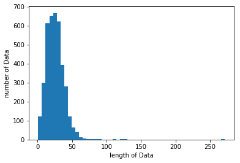

```python
%matplotlib inline
import matplotlib.pyplot as plt

plt.hist([len(s) for s in sentences], bins=50)
plt.xlabel('length of Data')
plt.ylabel('number of Data')
plt.show()
```

위의 그래프는 샘플의 길이가 대부분 0~50의 길이를 가지는 것을 보여줍니다.

훈련 데이터에서 sentences를 X로, pos_tags를 y로 하여 X와 y를 분리한 셈입니다. 이제 X에 대한 단어 집합과 y에 대한 단어 집합을 만들어보겠습니다.

```python
from collections import Counter
vocab=Counter()
tag_set=set()

for sentence in sentences: # 훈련 데이터 X에서 문장 샘플을 1개씩 꺼내온다.
  for word in sentence: # 샘플에서 단어를 1개씩 꺼내온다.
    vocab[word.lower()]=vocab[word.lower()]+1 # 각 단어의 빈도수를 카운트한다.

for tags_list in pos_tags: # 훈련 데이터 y에서 품사 태깅 정보 샘플을 1개씩 꺼내온다.
  for tag in tags_list: # 샘플에서 품사 태깅 정보를 1개씩 꺼내온다.
    tag_set.add(tag) # 각 품사 태깅 정보에 대해서 중복을 허용하지 않고 집합을 만든다.
```

```python
print(len(vocab)) # X 데이터의 단어 집합의 길이 출력
print(len(tag_set)) # y 데이터의 단어 집합의 길이 출력
```

```
11387
46
```

각각의 길이를 출력하므로서 단어의 개수는 11,387개. 품사 태깅 정보의 개수는 46개임을 알 수 있습니다.

이제는 각 단어에 대해서 인덱스를 부여하고, 각 품사 태깅 정보에 대해서도 인덱스를 부여해보겠습니다.

```python
vocab_sorted=sorted(vocab.items(), key=lambda x:x[1], reverse=True)
print(vocab_sorted[:5])
```

```
[(',', 4885), ('the', 4764), ('.', 3828), ('of', 2325), ('to', 2182)]
```

단어의 인덱스를 부여하기 위한 기준으로는 빈도수를 사용하겠습니다. 이를 위해 기존에 만든 단어 집합을 빈도수가 큰 순서대로 정렬합니다.

','가 4,885번 등장하여 최다 빈도수를 가진 단어이고, 두번째로는 the가 4,764번 등장하여 두번째로 빈도수가 높은 단어임을 확인할 수 있습니다.

이제 빈도수가 높은 순서대로 정렬된 단어 집합에 대해서 순차적으로 인덱스를 부여합니다. 단, 이 때 뒤에서 모든 문장 샘플의 길이를 맞추기 위한 'PAD'와 모르는 단어를 의미하는 'OOV'도 넣어줍니다.

```python
word_to_index={'PAD' : 0, 'OOV' :1}
i=1
# 인덱스 0은 각각 입력값들의 길이를 맞추기 위한 PAD(padding을 의미)라는 단어에 사용된다.
# 인덱스 1은 모르는 단어를 의미하는 OOV라는 단어에 사용된다.
for (word, frequency) in vocab_sorted :
    # if frequency > 1 :
    # 빈도수가 1인 단어를 제거하는 것도 가능하겠지만 이번에는 별도 수행하지 않고 해보겠음.
    # 참고로 제거를 수행할 경우 단어 집합의 크기가 절반 정도로 줄어듬.
        i=i+1
        word_to_index[word]=i
print(word_to_index)
print(len(word_to_index))
```

```
{'PAD': 0, 'OOV': 1, ',': 2, 'the': 3, '.': 4, 'of': 5, 'to': 6, 'a': 7, 'in': 8, 'and': 9, '*-1': 10, '0': 11, '*': 12, "'s": 13, 'for': 14, 'that': 15, '*t*-1': 16, '*u*': 17, '$': 18, '``': 19, "''": 20, 'is': 21, 'said': 22, 'it': 23, 'on': 24, '%': 25, 'by': 26, 'at': 27, 'as': 28, 'with': 29, …
11389
```

기존 단어 집합의 길이는 11,387였으나 'PAD'와 'OOV'를 추가하므로서 길이가 11,389가 된 것을 확인할 수 있습니다.

이제 word_to_index를 통해 단어를 입력하면, 인덱스를 리턴받을 수 있습니다.

```python
word_to_index['the']
```

```
3
```

이제 태깅 정보에 인덱스를 부여하고, 입력받은 품사 태깅 정보에 대해서 인덱스를 리턴하는 tag_to_index를 만들어보겠습니다.

```python
tag_to_index={'PAD' : 0}
i=0
for tag in tag_set:
    i=i+1
    tag_to_index[tag]=i
print(tag_to_index)
```

```
{'PAD': 0, 'VBZ': 1, 'VBN': 2, 'NNPS': 3, 'FW': 4, "''": 5, 'IN': 6, 'POS': 7, ',': 8, 'TO': 9, 'VBG': 10, 'VB': 11, 'PRP': 12, 'NNS': 13, 'LS': 14, 'DT': 15, 'NNP': 16, 'PRP$': 17, 'WP$': 18, 'NN': 19, 'JJ': 20, 'CC': 21, '``': 22, 'CD': 23, 'VBP': 24, '-LRB-': 25, '-RRB-': 26, 'UH': 27, 'MD': 28, …
```

총 46개의 단어를 가진 단어 집합에 대해서 인덱스가 부여었습니다. 패딩을 위해서 'PAD'라는 단어에는 인덱스 0을 부여하였습니다.

```python
len(tag_to_index)
```

```
47
```

단어 'PAD'가 추가되면서 단어 집합의 크기는 46에서 47이 되었습니다.

이제 tag_to_index에다가 품사 태깅 정보를 입력하면 인덱스를 리턴받을 수 있습니다.

```python
tag_to_index['UH']
```

```
27
```

이제 훈련 데이터에 대해서 정수 인코딩할 준비가 끝났습니다. 이제 모든 훈련 데이터를 담고 있는 sentences와 pos_tags로부터 word_to_index와 tag_to_index를 통해 모든 훈련 데이터를 숫자로 바꿀 것입니다.

우선 word_to_index를 사용하여 단어에 대한 훈련 데이터인 data_X를 만듭니다.

```python
data_X = []

for s in sentences:
    temp_X = []
    for w in s:
        try:
            temp_X.append(word_to_index.get(w.lower(),1))
        except KeyError: # 단어 집합을 만들 때 별도로 단어를 제거하지 않았기 때문에 이 과정에서는 OOV가 존재하지는 않음.
            temp_X.append(word_to_index['OOV'])

    data_X.append(temp_X)
print(data_X[:5])
```

```
[[5602, 3747, 2, 2025, 87, 332, 2, 47, 2406, 3, 132, 28, 7, 2026, 333, 460, 2027, 4], [32, 3747, 21, 178, 5, 5603, 2916, 2, 3, 2917, 638, 148, 4], [2918, 5604, 2, 1137, 87, 332, 9, 603, 178, 5, 3748, 1047, 893, 894, 2, 35, 484, 10, 7, 2026, 333, 5, 52, 1048, 436, 2919, 4], [7, 639, 5, 1049, 640, 324…
```

변환이 되었는지 보기 위해서 첫번째 샘플에 대해서만 기존의 단어 시퀀스를 출력해보겠습니다.

```python
index_to_word={}
for key, value in word_to_index.items(): # 인덱스를 단어로 바꾸기 위해 index_to_word를 생성
    index_to_word[value] = key


temp = []
for index in data_X[0] : # 첫번째 문장 샘플 안의 인덱스들에 대해서
    temp.append(index_to_word[index]) # 다시 단어로 변환

print(sentences[0]) # 기존 문장 샘플 출력
print(temp) # 기존 문장 샘플 → 정수 인코딩 → 복원
```

```
['Pierre' 'Vinken' ',' '61' 'years' 'old' ',' 'will' 'join' 'the' 'board'
 'as' 'a' 'nonexecutive' 'director' 'Nov.' '29' '.']
['pierre', 'vinken', ',', '61', 'years', 'old', ',', 'will', 'join', 'the', 'board', 'as', 'a', 'nonexecutive', 'director', 'nov.', '29', '.']
```

이제 y에 해당하는 전체 데이터를 담고 있는 pos_tags에서 품사 태깅 정보에 해당되는 부분을 모아 data_y에 저장하는 작업을 수행해보겠습니다.

```python
data_y = []

for s in pos_tags:
    temp_y = []
    for w in s:
            temp_y.append(tag_to_index.get(w))

    data_y.append(temp_y)

print(data_y[0])
```

```
[16, 16, 8, 23, 13, 20, 8, 28, 11, 15, 19, 6, 15, 20, 19, 16, 23, 31]
```

이제 단어에 대한 훈련 데이터인 data_X와 품사 태깅 정보에 대한 훈련 데이터인 data_y가 만들어졌습니다.

양방향 LSTM 모델에 손쉽게 데이터를 입력으로 사용하기 위해서, 여기서는 모든 샘플의 길이를 동일하게 맞추도록 하겠습니다. 이에 따라 가장 길이가 긴 샘플의 길이를 우선 구해보겠습니다.

```python
print(max(len(l) for l in data_X)) # 모든 데이터에서 길이가 가장 긴 샘플의 길이 출력
print(max(len(l) for l in data_y)) # 모든 데이터에서 길이가 가장 긴 샘플의 길이 출력
```

```
271
271
```

길이가 가장 긴 샘플의 길이는 271입니다. 그런데 앞서 본 그래프에 따르면, 대부분의 샘플은 길이가 50이하입니다. X에 해당되는 데이터 data_X의 샘플들과 y에 해당되는 데이터 data_y 샘플들의 모든 길이를 임의로 150정도로 맞추어 보겠습니다. 이를 위해서 케라스의 pad_sequences()를 사용합니다.

```python
max_len=150
from keras.preprocessing.sequence import pad_sequences
pad_X = pad_sequences(data_X, padding='post', maxlen=max_len)
# data_X의 모든 샘플의 길이를 맞출 때 뒤의 공간에 숫자 0으로 채움.
pad_y = pad_sequences(data_y, padding='post', value=tag_to_index['PAD'], maxlen=max_len)
# data_y의 모든 샘플의 길이를 맞출 때 뒤의 공간에 'PAD'에 해당되는 인덱스로 채움.
# 참고로 숫자 0으로 채우는 것과 'PAD'에 해당하는 인덱스로 채우는 것은 결국 0으로 채워지므로 같음
```

전체 훈련 데이터에서 길이가 가장 짧은 샘플의 길이를 출력했을 때 150이 나오는지 확인합니다.

```python
print(min(len(l) for l in pad_X)) # 모든 데이터에서 길이가 가장 짧은 샘플의 길이 출력
print(min(len(l) for l in pad_y)) # 모든 데이터에서 길이가 가장 짧은 샘플의 길이 출력
150
150
```

```
150
150
```

[output not shown]

pad_X와 pad_y를 훈련 데이터와 테스트 데이터로 8:2로 분할합니다.

```python
from sklearn.model_selection import train_test_split
X_train, X_test, y_train, y_test = train_test_split(pad_X, pad_y, test_size=.2, random_state=777)
```

random_state를 지정했기 때문에 기존의 pad_X와 pad_y에서 순서가 섞이면서 훈련 데이터와 테스트 데이터로 분할됩니다.

```python
from keras.utils import np_utils
y_train2 = np_utils.to_categorical(y_train)
```

훈련 데이터 y_train에 대해서 원-핫 인코딩을 수행하고 y_train2에 저장합니다.

```python
from keras.models import Sequential
from keras.layers import Dense, LSTM, InputLayer, Bidirectional, TimeDistributed, Embedding
from keras.optimizers import Adam

n_words = len(word_to_index)
n_labels = len(tag_to_index)

model = Sequential()
model.add(Embedding(n_words, 128, input_length=max_len, mask_zero=True))
model.add(Bidirectional(LSTM(256, return_sequences=True)))
model.add(TimeDistributed(Dense(n_labels, activation=('softmax'))))
model.compile(loss='categorical_crossentropy',optimizer=Adam(0.001),metrics=['accuracy'])
```

```python
model.fit(X_train, y_train2, batch_size=128, epochs=6)
```

```
<keras.callbacks.History at 0x1c2aea41ba8>
```

```python
y_test2 = np_utils.to_categorical(y_test)
print("\n 테스트 정확도: %.4f" % (model.evaluate(X_test, y_test2)[1]))
```

```
 테스트 정확도: 0.9299
```

우선 인덱스로부터 단어와 품사 태깅 정보를 리턴하는 index_to_word와 index_to_tag를 만들고 이를 이용하여 실제값과 예측값을 출력합니다.

```python
import numpy as np

index_to_word={}
for key, value in word_to_index.items():
    index_to_word[value] = key

index_to_tag={}
for key, value in tag_to_index.items():
    index_to_tag[value] = key


i=10 # 확인하고 싶은 테스트용 샘플의 인덱스.
y_predicted = model.predict(np.array([X_test[i]])) # 입력한 테스트용 샘플에 대해서 예측 y를 리턴
y_predicted = np.argmax(y_predicted, axis=-1) # 원-핫 인코딩을 다시 정수 인코딩으로 변경함.
true = np.argmax(y_test2[i], -1) # 원-핫 인코딩을 다시 정수 인코딩으로 변경함.

print("{:15}|{:5}|{}".format("단어", "실제값", "예측값"))
print(35 * "-")

for w, t, pred in zip(X_test[i], true, y_predicted[0]):
    if w != 0: # PAD값은 제외함.
        print("{:17}: {:7} {}".format(index_to_word[w], index_to_tag[t], index_to_tag[pred]))
```

```
단어             |실제값  |예측값
-----------------------------------
in               : IN      IN
addition         : NN      NN
,                : ,       ,
buick            : NNP     NNP
is               : VBZ     VBZ
a                : DT      DT
relatively       : RB      RB
respected        : VBN     VBN
nameplate        : NN      NN
among            : IN      IN
american         : NNP     NNP
express          : NNP     NNP
card             : NN      NN
holders          : NNS     NNS
,                : ,       ,
says             : VBZ     VBZ
0                : -NONE-  -NONE-
*t*-1            : -NONE-  -NONE-
an               : DT      DT
american         : NNP     NNP
express          : NNP     NNP
spokeswoman      : NN      NN
.                : .       .
```

## 5. 양방향 LSTM과 CRF(Bidirectional LSTM + CRF)

기존의 양방향 LSTM 모델에 CRF(Conditional Random Field)라는 새로운 층을 추가하여 보다 모델을 개선시킨 양방향 LSTM + CRF 모델을 사용하여 개체명 인식(Named Entity Recognition)을 수행합니다.

- 논문 링크 : https://arxiv.org/pdf/1508.01991v1.pdf
- 논문 링크 : https://arxiv.org/pdf/1603.01360.pdf

### 1) CRF(Conditional Random Field)

CRF는 Conditional Random Field의 약자로 양방향 LSTM을 위해 탄생한 모델이 아니라 이전에 독자적으로 존재해왔던 모델입니다.

양방향 LSTM 모델의 위에 CRF를 하나의 층으로 추가하여, 양방향 LSTM + CRF 모델이 탄생하였습니다.

CRF 층의 역할을 이해하기 위해서 간단한 개체명 인식 작업의 예를 들어보겠습니다. 사람(Person), 조직(Organization) 두 가지만을 태깅하는 간단한 태깅 작업에 BIO 표현을 사용한다면 여기서 사용하는 태깅의 종류는 아래의 5가지입니다.

B-Per, I-Per, B-Org, I-Org, O

아래의 그림은 위의 태깅을 수행하는 기존의 양방향 LSTM 개체명 인식 모델의 예를 보여줍니다.

[figure not shown]

위 모델은 각 단어를 벡터로 입력받고, 모델의 출력층에서 활성화 함수를 통해 개체명을 예측합니다.

사실 입력 단어들과 실제 개체명이 무엇인지 모르는 상황이므로 이 모델이 정확하게 개체명을 예측했는지는 위 그림만으로는 알 수 없습니다.

[figure not shown]

위 모델은 명확히 틀린 예측을 포함하고 있습니다.

BIO 표현에 따르면 우선, 첫번째 단어에서 I가 갑자기 등장할 수 없습니다. 또한 I-Per은 반드시 B-Per 뒤에서만 등장할 수 있습니다. 뿐만 아니라, I-Org도 마찬가지로 B-Org 뒤에서만 등장할 수 있는데 위 모델은 이런 BIO 표현 방법의 제약사항들을 모두 위반하고 있습니다.

CRF 층을 추가하면 모델은 예측 개체명, 다시 말해 레이블 사이의 의존성을 고려할 수 있습니다. 아래의 그림은 양방향 LSTM + CRF 모델을 보여줍니다.

[figure not shown]

기존에 CRF 층이 존재하지 않았던 양방향 LSTM 모델은 활성화 함수를 지난 시점에서 개체명을 결정했지만, CRF 층을 추가한 모델에서는 활성화 함수의 결과들이 CRF 층의 입력으로 전달됩니다.

예를 들어 word1에 대한 Bi-LSTM 셀과 활성화 함수를 지난 출력값 [0.7, 0.12, 0.08, 0.04, 0.06]은 CRF 층의 입력이 됩니다. CRF 층은 레이블 시퀀스에 대해서 가장 높은 점수를 가지는 시퀀스를 예측합니다.

CRF 층은 점차적으로 훈련 데이터로부터 아래와 같은 제약사항 등을 학습하게 됩니다.

1. 문장의 첫번째 단어에서는 I가 나오지 않습니다.
2. O-I 패턴은 나오지 않습니다.
3. B-I-I 패턴에서 개체명은 일관성을 유지합니다. 예를 들어 B-Per 다음에 I-Org는 나오지 않습니다.

CRF를 사용하기 위해 keras_contrib를 설치해야 합니다. 아래의 명령을 수행하여 설치합니다.

```python
# pip install git+https://www.github.com/keras-team/keras-contrib.git
```

### 2) 양방향 LSTM + CRF을 이용한 개체명 인식

양방향 LSTM과 CRF를 함께 사용하여 앞서 사용한 데이터 외에 다른 데이터를 사용하여 개체명 인식을 수행해보도록 하겠습니다.

데이터 링크 : https://www.kaggle.com/abhinavwalia95/entity-annotated-corpus

```python
import pandas as pd
import numpy as np

data = pd.read_csv("ner_dataset.csv", encoding="latin1")
```

```python
data[:5]
```

|  | Sentence # | Word | POS | Tag |
| --- | --- | --- | --- | --- |
| 0 | Sentence: 1 | Thousands | NNS | O |
| 1 | NaN | of | IN | O |
| 2 | NaN | demonstrators | NNS | O |
| 3 | NaN | have | VBP | O |
| 4 | NaN | marched | VBN | O |

첫번째 열은 다음과 같은 패턴을 가지고 있습니다. Sentence: 1 있고, Null 값이 이어지다가 다시 Sentence: 2가 나오고 다시 Null 값이 이어지다가 Sentence: 3이 나오고 다시 Null 값이 이어지다가를 반복합니다. 그런데 사실 이는 하나의 문장을 여러 행으로 나눠놓은 것입니다. 숫자값을 t라고 합시다.

첫번째 Sentence: t부터 Null 값이 나오다가 Sentence: t+1이 나오기 전까지의 모든 데이터는 원래 하나의 행. 즉, 하나의 샘플이어야 합니다. t번째 문장을 각 단어마다 각 하나의 행으로 나눠놓은 데이터이기 때문입니다. 이는 뒤에서 Pandas의 fillna를 통해 하나로 묶는 작업을 해줍니다.

```python
len(data)
```

```
1048575
```

현재 data의 행의 개수는 1,048,575개입니다. 하지만 뒤에서 기존에 문장 1개였던 행들을 1개의 행으로 병합하는 작업을 해야하기 때문에 최종 샘플의 개수는 이보다 줄어들게 됩니다.

```python
data.isnull().values.any()
```

```
True
```

Sentence #열에 Null 값들이 존재

```python
data.isnull().sum()
```

```
Sentence #    1000616
Word                0
POS                 0
Tag                 0
dtype: int64
```

isnull().sum()을 수행하면 각 열마다의 Null 값의 개수를 보여줍니다. 다른 열은 0개인데 오직 Sentences #열에서만 1,000,616개가 나온 것을 볼 수 있습니다.

전체 데이터에서 중복을 허용하지 않고, 유일한 값의 개수를 셀 수 있게 해주는 nunique()를 사용해봅시다.

```python
data['Sentence #'].nunique(), data.Word.nunique(), data.Tag.nunique()
```

```
(47959, 35178, 17)
```

이 데이터에는 47,959개의 문장이 있으며 문장들은 35,178개의 단어를 가지고 17개 종류의 개체명 태깅을 가집니다.

17개의 개체명 태깅이 전체 데이터에서 몇 개가 있는지, 개체명 태깅 개수의 분포를 확인해보도록 하겠습니다.

```python
print(data.groupby('Tag').size().reset_index(name='count'))
```

```
      Tag   count
0   B-art     402
1   B-eve     308
2   B-geo   37644
3   B-gpe   15870
4   B-nat     201
5   B-org   20143
6   B-per   16990
7   B-tim   20333
8   I-art     297
9   I-eve     253
10  I-geo    7414
11  I-gpe     198
12  I-nat      51
13  I-org   16784
14  I-per   17251
15  I-tim    6528
16      O  887908
```

BIO 표현 방법에서 아무런 태깅도 의미하지 않는 O가 가장 887,908개로 가장 많은 개수를 차지함을 볼 수 있습니다.

이제 데이터를 원하는 형태로 가공해보겠습니다. 우선 Null 값을 제거합니다.

```python
data = data.fillna(method="ffill")
```

Pandas의 (method='ffill')는 Null 값을 가진 행의 바로 앞의 행의 값으로 Null 값을 채우는 작업을 수행합니다. 이렇게 하면 t번째 문장에 속하면서 Null 값을 가진 샘플들은 전부 첫번째 열에 Sentence: t의 값이 들어갑니다.

이번에는 뒤의 5개의 샘플을 출력해서 정상적으로 수행되었는지 확인해봅시다.

```python
print(data.tail())
```

```
              Sentence #       Word  POS Tag
1048570  Sentence: 47959       they  PRP   O
1048571  Sentence: 47959  responded  VBD   O
1048572  Sentence: 47959         to   TO   O
1048573  Sentence: 47959        the   DT   O
1048574  Sentence: 47959     attack   NN   O
```

전체 데이터에 Null 값이 여전히 존재하는지 확인해봅시다.

```python
data.isnull().values.any()
```

```
False
```

모든 단어를 소문자화하여 단어의 개수를 줄여보겠습니다.

```python
data['Word'] = data['Word'].str.lower()
# 단어의 소문자화. 이 데이터의 경우 이를 통해 약 3,000개의 중복 단어 제거 가능.
```

```python
print(data[:5])
```

```
    Sentence #           Word  POS Tag
0  Sentence: 1      thousands  NNS   O
1  Sentence: 1             of   IN   O
2  Sentence: 1  demonstrators  NNS   O
3  Sentence: 1           have  VBP   O
4  Sentence: 1        marched  VBN   O
```

이제 중복을 허용하지 않고, 단어들을 모아 단어 집합을 만들도록 하겠습니다.

```python
vocab=(list(set(data["Word"].values))) # 중복을 허용하지 않고 집합으로 만듬.
print(len(vocab)) # 단어 집합의 크기
print(vocab[:5]) # 단어 집합 출력
```

```
31817
['songwriter', 'zach', 'sprinters', 'december', "o'connor"]
```

단어의 수가 35,178에서 31,817로 줄어든 것을 볼 수 있습니다. 단어들을 소문자화하여 대문자, 소문자로 표기만 다른 중복 단어들이 하나의 단어들로 정규화되었기 때문입니다.

태깅 정보에 대해서도 중복을 허용하지 않고 태깅 정보 집합을 만듭니다.

```python
tags = list(set(data["Tag"].values)) # 중복을 허용하지 않고 집합으로 만듬.
print(len(tags)) # 태깅 정보 집합의 크기
print(tags) # 태깅 정보 출력
```

```
17
['B-gpe', 'B-org', 'I-geo', 'I-per', 'B-nat', 'I-eve', 'B-per', 'B-geo', 'I-art', 'B-eve', 'O', 'I-org', 'B-tim', 'I-nat', 'I-gpe', 'B-art', 'I-tim']
```

geo는 Geographical Entity  
org는 Organization  
per는 Person  
gpe는 Geopolitical Entity  
tim은 Time indicator  
art는 Artifact  
eve는 Event  
nat는 Natural Phenomenon

품사 태깅 정보는 고려하지 않고 개체명 인식을 진행하므로, 품사 태깅 정보에 해당되는 열을 삭제해보도록 하겠습니다.

```python
del data['POS']
print(data[:5])
```

```
    Sentence #           Word Tag
0  Sentence: 1      thousands   O
1  Sentence: 1             of   O
2  Sentence: 1  demonstrators   O
3  Sentence: 1           have   O
4  Sentence: 1        marched   O
```

이제 하나의 문장에 등장한 단어와 개체명 태깅 정보끼리 쌍(pair)으로 묶는 작업을 수행합니다.

```python
func = lambda temp: [(w, t) for w, t in zip(temp["Word"].values.tolist(), temp["Tag"].values.tolist())]
All_data=[t for t in data.groupby("Sentence #").apply(func)]
print(len(All_data))
```

```
47959
```

```python
print(All_data[0])
print(len(All_data[0]))
```

```
[('thousands', 'O'), ('of', 'O'), ('demonstrators', 'O'), ('have', 'O'), ('marched', 'O'), ('through', 'O'), ('london', 'B-geo'), ('to', 'O'), ('protest', 'O'), ('the', 'O'), ('war', 'O'), ('in', 'O'), ('iraq', 'B-geo'), ('and', 'O'), ('demand', 'O'), ('the', 'O'), ('withdrawal', 'O'), ('of', 'O'), …
24
```

하나의 문장에 등장한 단어와 개체명 태깅 정보끼리 쌍으로 묶인 것을 볼 수 있습니다.

전체 데이터 샘플의 길이 분포를 확인해봅시다.

```
샘플의 최대 길이 : 104
샘플의 평균 길이 : 21.863987989741236
```

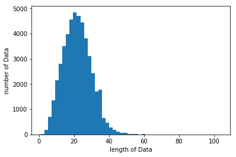

```python
%matplotlib inline
import matplotlib.pyplot as plt

print('샘플의 최대 길이 :',max(len(l) for l in All_data))
print('샘플의 평균 길이 :',sum(map(len, All_data))/len(All_data))

plt.hist([len(s) for s in All_data], bins=50)
plt.xlabel('length of Data')
plt.ylabel('number of Data')
plt.show()
```

이제 단어와 개체명 태깅 정보를 분리하는 작업을 진행합니다. 즉, 레이블을 분리하는 작업입니다.

```python
import numpy as np

sentences, ner_tags =[], []
for tagged_sentence in All_data:
    sentence, ner_info = zip(*tagged_sentence) # 각 샘플에서 단어는 sentence에 개체명 태깅정보는 ner_info에
    sentences.append(np.array(sentence)) # 각 샘플에서 단어 정보만 저장한다.
    ner_tags.append(np.array(ner_info)) # 각 샘플에서 개체명 태깅 정보만 저장한다.
```

```python
print(sentences[0])
```

```
['thousands' 'of' 'demonstrators' 'have' 'marched' 'through' 'london' 'to'
 'protest' 'the' 'war' 'in' 'iraq' 'and' 'demand' 'the' 'withdrawal' 'of'
 'british' 'troops' 'from' 'that' 'country' '.']
```

```python
print(ner_tags[0])
```

```
['O' 'O' 'O' 'O' 'O' 'O' 'B-geo' 'O' 'O' 'O' 'O' 'O' 'B-geo' 'O' 'O' 'O'
 'O' 'O' 'B-gpe' 'O' 'O' 'O' 'O' 'O']
```

단어 집합의 경우에는 Counter()를 이용하여 단어의 등장 빈도수를 계산하는 작업도 함께 진행합니다.

```python
from collections import Counter
vocab=Counter()
tag_set=set()

for sentence in sentences: # 훈련 데이터 X에서 샘플을 1개씩 꺼내온다.
    for word in sentence: # 샘플에서 단어를 1개씩 꺼내온다.
        vocab[word.lower()]=vocab[word.lower()]+1 # 각 단어의 빈도수를 카운트한다.

for tags_list in ner_tags: # 훈련 데이터 y에서 샘플을 1개씩 꺼내온다.
    for tag in tags_list: # 샘플에서 개체명 정보를 1개씩 꺼내온다.
        tag_set.add(tag) # 각 개체명 정보에 대해서 중복을 허용하지 않고 집합을 만든다.
```

```python
vocab
```

```
Counter({'thousands': 495,
         'of': 26378,
         'demonstrators': 132,
         'have': 5486,
         'marched': 65,
         'through': 518,
         'london': 261,
         'to': 23249,
         'protest': 238,
         'the': 63905,
         'war': 903,
         'in': 28050,
         'iraq': 1738,
         'and': 20116,
         'demand': 221,
         'withdrawal': 154,
         'british': 637,
         'troops': 1202,
         'from': 4557,
         'that': 6437,
         'country': 1934,
         '.': 47761,
         'iranian': 380,
         'officials': 3390,
         'say': 4178,
         'they': 2397,
         'expect': 66,
         'get': 170,
         'access': 127,
         'sealed': 18,
         'sensitive': 30,
         'parts': 168,
         'plant': 109,
         'wednesday': 1258,
         ',': 32754,
         'after': 2737,
         'an': 4236,
         'iaea': 73,
         'surveillance': 51,
         'system': 267,
```

[output cut: 946 more lines]

```
         'respect': 40,
         'iraqi': 1144,
         'arab-islamic': 1,
         'culture': 27,
         'there': 823,
         'word': 50,
         'fate': 44,
         'following': 476,
         'threat': 168,
         'kidnappers': 84,
         'execute': 4,
         'unless': 84,
         'eight': 290,
         'detainees': 172,
         ...})
```

```python
print(tag_set)
```

```
{'B-gpe', 'B-org', 'I-geo', 'I-per', 'B-nat', 'I-eve', 'B-per', 'B-geo', 'I-art', 'B-eve', 'O', 'I-org', 'B-tim', 'I-nat', 'I-gpe', 'B-art', 'I-tim'}
```

```python
print(len(vocab)) # X 데이터의 단어 집합의 크기 출력
print(len(tag_set)) # y 데이터의 집합의 크기 출력 (개체명 태깅 정보의 종류 출력)
```

```
31817
17
```

단어 집합의 크기는 31,817입니다. 개체명 태깅 정보는 총 17개의 종류가 존재합니다.

이제 단어 집합을 등장 빈도수를 기준으로 정렬합니다.

```python
vocab_sorted=sorted(vocab.items(), key=lambda x:x[1], reverse=True)
print(vocab_sorted[:5])
```

```
[('the', 63905), ('.', 47761), (',', 32754), ('in', 28050), ('of', 26378)]
```

'the'가 63,905번의 빈도수로 가장 많이 등장하였고, 불용어에 속하는 각종 전치사들 또한 등장 빈도수가 굉장히 높게 나옵니다.

이제 단어 집합의 각 단어에 인덱스를 부여해보도록 하겠습니다.

```python
word_to_index={'PAD' : 0, 'OOV' :1}
i=1
# 인덱스 0은 각각 입력값들의 길이를 맞추기 위한 PAD(padding을 의미)라는 단어에 사용된다.
# 인덱스 1은 모르는 단어를 의미하는 OOV라는 단어에 사용된다.
for (word, frequency) in vocab_sorted :
    # if frequency > 1 :
    # 빈도수가 1인 단어를 제거하는 것도 가능하겠지만 이번에는 별도 수행하지 않고 진행함.
        i=i+1
        word_to_index[word]=i
print(word_to_index)
print(len(word_to_index))
```

```
{'PAD': 0, 'OOV': 1, 'the': 2, '.': 3, ',': 4, 'in': 5, 'of': 6, 'to': 7, 'a': 8, 'and': 9, "'s": 10, 'for': 11, 'has': 12, 'on': 13, 'is': 14, 'that': 15, 'have': 16, 'with': 17, 'said': 18, 'was': 19, 'at': 20, 'says': 21, 'from': 22, 'by': 23, 'he': 24, 'an': 25, 'as': 26, 'say': 27, 'u.s.': 28, …
31819
```

인덱스 0에는 패딩을 위한 'PAD'를 집어놓고, 인덱스 1에는 모르는 단어를 의미하는 'OOV'를 집어넣습니다. 그 이후에는 빈도수 순대로 인덱스를 부여합니다. 여기서는 빈도수 1인 단어를 별도로 제거하지 않았는데, 만약 제거 한다면 뒤에서 각 문장에 대해서 정수 인코딩을 진행할 때 단어 집합이 모르는 단어가 발생하므로 그런 상황에서 'OOV'로 판단하여 인덱스 1을 사용할 수 있습니다.

이제 태깅 정보에도 인덱스를 부여해보겠습니다.

```python
tag_to_index={'PAD' : 0}
i=0
for tag in tag_set:
    i=i+1
    tag_to_index[tag]=i
print(tag_to_index)
```

```
{'PAD': 0, 'B-gpe': 1, 'B-org': 2, 'I-geo': 3, 'I-per': 4, 'B-nat': 5, 'I-eve': 6, 'B-per': 7, 'B-geo': 8, 'I-art': 9, 'B-eve': 10, 'O': 11, 'I-org': 12, 'B-tim': 13, 'I-nat': 14, 'I-gpe': 15, 'B-art': 16, 'I-tim': 17}
```

이제 임의의 단어와 태깅 정보에 대해서 인덱스가 출력되는지 시험해봅시다.

```python
print(word_to_index["walled"])
print(tag_to_index["B-geo"])
```

```
31754
8
```

이제 정수 인코딩을 진행해보겠습니다.

```python
data_X = []

for s in sentences: # 전체 데이터에서 하나의 데이터. 즉, 하나의 문장씩 불러옵니다.
    temp_X = []
    for w in s: # 각 문장에서 각 단어를 불러옵니다.
        temp_X.append(word_to_index.get(w,1)) # 각 단어를 맵핑되는 인덱스로 변환합니다.
    data_X.append(temp_X)
```

```python
len(data_X)
```

```
47959
```

총 샘플의 개수는 47,959으로 정수 인코딩이 되기 전과 동일합니다. 첫번째 샘플을 출력해보겠습니다.

```python
print(data_X[0])
```

```
[254, 6, 967, 16, 1795, 238, 468, 7, 523, 2, 129, 5, 61, 9, 571, 2, 833, 6, 186, 90, 22, 15, 56, 3]
```

이제 데이터의 y에 해당되는 개체명 태깅 정보 또한 정수 인코딩을 진행하겠습니다.

```python
data_y = []
for s in ner_tags:
    temp_y = []
    for w in s:
            temp_y.append(tag_to_index.get(w))
    data_y.append(temp_y)
print(data_y[0]) # 첫번째 데이터 출력
```

```
[11, 11, 11, 11, 11, 11, 8, 11, 11, 11, 11, 11, 8, 11, 11, 11, 11, 11, 1, 11, 11, 11, 11, 11]
```

이제 X 데이터와 y 데이터가 구성되었습니다.

```python
max_len=70
from keras.preprocessing.sequence import pad_sequences
pad_X = pad_sequences(data_X, padding='post', maxlen=max_len)
# data_X의 모든 샘플의 길이를 패딩할 때 뒤의 공간에 숫자 0으로 채움.
pad_y = pad_sequences(data_y, padding='post', value=tag_to_index['PAD'], maxlen=max_len)
# data_y의 모든 샘플의 길이를 패딩할 때 'PAD'에 해당되는 인덱스로 채움.
# 결과적으로 'PAD'의 인덱스값인 0으로 패딩된다.
```

모든 샘플의 길이가 70이 되었습니다.

```python
from sklearn.model_selection import train_test_split
X_train, X_test, y_train, y_test = train_test_split(pad_X, pad_y, test_size=.1, random_state=777)
```

훈련 데이터와 테스트 데이터를 분리합니다. 모델을 설계해보겠습니다.

```python
from keras.models import Sequential
from keras.layers import LSTM, Embedding, Dense, TimeDistributed, Dropout, Bidirectional
from keras_contrib.layers import CRF
```

```python
n_words = len(word_to_index)
n_labels = len(tag_to_index)
```

```python
model = Sequential()
model.add(Embedding(input_dim=n_words, output_dim=20, input_length=max_len, mask_zero=True))
model.add(Bidirectional(LSTM(units=50, return_sequences=True, recurrent_dropout=0.1)))
model.add(TimeDistributed(Dense(50, activation="relu")))
crf = CRF(n_labels)
model.add(crf)
```

모델에 양방향 LSTM을 사용하고, 모델의 출력층에 CRF 층을 배치합니다.

```python
from keras.utils import np_utils
y_train2 = np_utils.to_categorical(y_train) #원-핫 인코딩
y_train2[0][0]
```

```
array([0., 0., 0., 0., 0., 0., 0., 0., 0., 0., 0., 1., 0., 0., 0., 0., 0.,
       0.], dtype=float32)
```

훈련 데이터 y_train에 대해서 원-핫 인코딩을 수행하고 y_train2에 저장합니다.

```python
model.compile(optimizer="rmsprop", loss=crf.loss_function, metrics=[crf.accuracy])
history = model.fit(X_train, y_train2, batch_size=32, epochs=5, validation_split=0.1, verbose=1)
```

```
Train on 38846 samples, validate on 4317 samples
```

```python
y_test2 = np_utils.to_categorical(y_test)
print("\n 테스트 정확도: %.4f" % (model.evaluate(X_test, y_test2)[1]))
```

```
 테스트 정확도: 0.9605
```

96%의 정확도를 얻어냅니다. 뒤에서 좀 더 알맞은 방법으로 정확도를 측정해볼겁니다.

```python
index_to_word={}
for key, value in word_to_index.items():
    index_to_word[value] = key

index_to_tag={}
for key, value in tag_to_index.items():
    index_to_tag[value] = key


i=13 # 확인하고 싶은 테스트용 샘플의 인덱스.
y_predicted = model.predict(np.array([X_test[i]])) # 입력한 테스트용 샘플에 대해서 예측 y를 리턴
y_predicted = np.argmax(y_predicted, axis=-1) # 원-핫 인코딩을 다시 정수 인코딩으로 변경함.
true = np.argmax(y_test2[i], -1) # 원-핫 인코딩을 다시 정수 인코딩으로 변경함.

print("{:15}|{:5}|{}".format("단어", "실제값", "예측값"))
print(35 * "-")

for w, t, pred in zip(X_test[i], true, y_predicted[0]):
    if w != 0: # PAD값은 제외함.
        print("{:17}: {:7} {}".format(index_to_word[w], index_to_tag[t], index_to_tag[pred]))
```

```
단어             |실제값  |예측값
-----------------------------------
the              : O       O
statement        : O       O
came             : O       O
as               : O       O
u.n.             : B-org   B-org
secretary-general: I-org   I-org
kofi             : B-per   B-per
annan            : I-per   I-per
met              : O       O
with             : O       O
officials        : O       O
in               : O       O
amman            : B-geo   B-geo
to               : O       O
discuss          : O       O
wednesday        : B-tim   B-tim
's               : O       O
attacks          : O       O
.                : O       O
```

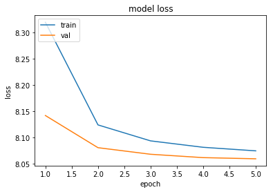

```python
epochs = range(1, len(history.history['val_loss']) + 1)
plt.plot(epochs, history.history['loss'])
plt.plot(epochs, history.history['val_loss'])
plt.title('model loss')
plt.ylabel('loss')
plt.xlabel('epoch')
plt.legend(['train', 'val'], loc='upper left')
plt.show()
```

### 3) 시퀀스 레이블링 평가하기

개체명 인식에서는 그 어떤 개체도 아니라는 의미의 'O'라는 태깅이 존재합니다. 그런데 이런 정보는 보통 대다수의 레이블을 차지하기 때문에 기존에 사용했던 정확도 평가 방법을 사용하는 것이 적절하지 않을 수 있습니다.

실제로는 PER, MISC, PER, MISC, PER이라는 총 5개의 개체가 존재함에도 불구하고 예측값인 predicted는 단 1개의 개체도 맞추지 못한 상황을 시뮬레이션을 해봅시다. 개체를 하나도 맞추지 못했다는 가정하에 전부 'O'로만 채워진 예측값 predicted를 생성합니다.

```python
true=['B-PER', 'I-PER', 'O', 'O', 'B-MISC', 'O','O','O','O','O','O','O','O','O','O','B-PER','I-PER','O','O','O','O','O','O','B-MISC','I-MISC','I-MISC','O','O','O','O','O','O','B-PER','I-PER','O','O','O','O','O']
# 실제값
predicted=['O'] * len(true) #실제값의 길이만큼 전부 'O'로 채워진 리스트 생성. 예측값으로 사용.
print(predicted)
```

```
['O', 'O', 'O', 'O', 'O', 'O', 'O', 'O', 'O', 'O', 'O', 'O', 'O', 'O', 'O', 'O', 'O', 'O', 'O', 'O', 'O', 'O', 'O', 'O', 'O', 'O', 'O', 'O', 'O', 'O', 'O', 'O', 'O', 'O', 'O', 'O', 'O', 'O', 'O']
```

이제 시뮬레이션에 대한 정확도를 계산해봅시다.

```python
hit = 0 # 정답 개수
for t, p in zip(true, predicted):
    if t == p:
        hit +=1 # 정답인 경우에만 +1
accuracy = hit/len(true) # 정답 개수를 총 개수로 나눈다.
print("정확도: {:.1%}".format(accuracy))
```

```
정확도: 74.4%
```

#### 문제점 (모델의 성능의 오해를 불러 일으킬 수 있다.)

실제값에서도 대부분의 값이 'O'이기 때문에 그 어떤 개체도 찾지 못하였음에도 74%의 정확도를 얻습니다. 이는 정확도가 뻥튀기되어 모델의 성능을 오해할 수 있다는 문제가 있습니다.

그래서 여기서는 위와 같은 상황에서 더 적절한 평가 방법을 도입하고자 합니다. 윈도우의 명령 프롬프트나 UNIX의 터미널에서 아래의 명령을 수행하여 파이썬 패키지 seqeval를 설치합니다.

#### 해경방법 (더 적절한 평가방법 사용, 패키지 seqeval사용)

```python
#pip install seqeval
```

평가방법으로 정밀도(precision)과 재현률(recall)를 사용한다.

$정밀도 = \frac{TP}{TP + FP} = \text{특정 개체라고 예측한 경우 중에서 실제 특정 개체로 판명되어 예측이 일치한 비율}$

$재현률 = \frac{TP}{TP + FN} = \text{전체 특정 개체 중에서 실제 특정 개체라고 정답을 맞춘 비율}$

정밀도와 재현률로부터 조화 평균(harmonic mean)을 구한 것을 f1-score라고 합니다.

$f1\ score = 2 × \frac{\text{정밀도 × 재현률}}{\text{정밀도 + 재현률}}$

predicted의 성능을 평가하기 위해서 정밀도, 재현률, f1-score를 계산해보도록 하겠습니다.

```python
from seqeval.metrics import precision_score, recall_score, f1_score, classification_report
print(classification_report(true, predicted))
```

```
           precision    recall  f1-score   support

     MISC       0.00      0.00      0.00         2
      PER       0.00      0.00      0.00         3

micro avg       0.00      0.00      0.00         5
macro avg       0.00      0.00      0.00         5
```

이러한 측정 방법을 사용하면 PER과 MISC 두 특정 개체 중에서 실제 predicted가 맞춘 것은 단 하나도 없는 것을 확인할 수 있습니다.

이번에는 어느 정도는 정답을 맞추었다고 가정하고 예측값인 predicted를 수정하여 정밀도, 재현률, f1-score를 확인해봅시다.

```python
true=['B-PER', 'I-PER', 'O', 'O', 'B-MISC', 'O','O','O','O','O','O','O','O','O','O','B-PER','I-PER','O','O','O','O','O','O','B-MISC','I-MISC','I-MISC','O','O','O','O','O','O','B-PER','I-PER','O','O','O','O','O']
predicted=['B-PER', 'I-PER', 'O', 'O', 'B-MISC', 'O','O','O','O','O','O','O','O','O','O','B-PER','I-PER','O','O','O','O','O','O','O','O','O','O','O','O','O','O','O','O','O','O','O','O','O','O']
print(classification_report(true, predicted))
```

```
           precision    recall  f1-score   support

     MISC       1.00      0.50      0.67         2
      PER       1.00      0.67      0.80         3

micro avg       1.00      0.60      0.75         5
macro avg       1.00      0.60      0.75         5
```

### 4) 실제 모델에 대해서 f1 score 구하기

이제 앞서 구현한 모델에 대해서 위에서 배운 f1-score를 적용해봅시다.

모델이 리턴하는 예측값은 숫자로 구성되어져 있으므로, 이를 먼저 태깅이 나열되어 있는 리스트로 치환하는 작업이 필요합니다.

sequences_to_tag (숫자 시퀀스로부터 태깅 정보로 치환)하는 함수를 만듭니다.

```python
def sequences_to_tag(sequences): # 예측값을 index_to_tag를 사용하여 태깅 정보로 변경하는 함수.
    result = []
    for sequence in sequences: # 전체 시퀀스로부터 시퀀스를 하나씩 꺼낸다.
        temp = []
        for pred in sequence: # 시퀀스로부터 예측값을 하나씩 꺼낸다.
            pred_index = np.argmax(pred) # 예를 들어 [0, 0, 1, 0 ,0]라면 1의 인덱스인 2를 리턴한다.
            temp.append(index_to_tag[pred_index].replace("PAD", "O")) # 'PAD'는 'O'로 변경
        result.append(temp)
    return result
```

```python
y_predicted = model.predict(X_test)
pred_tags = sequences_to_tag(y_predicted)
test_tags = sequences_to_tag(y_test2)
```

```python
print(classification_report(test_tags, pred_tags))
```

```
           precision    recall  f1-score   support

      org       0.72      0.54      0.61      2037
      per       0.76      0.78      0.77      1732
      tim       0.88      0.85      0.86      2016
      geo       0.83      0.87      0.85      3832
      gpe       0.97      0.94      0.96      1600
      art       0.00      0.00      0.00        32
      eve       0.00      0.00      0.00        28
      nat       0.00      0.00      0.00        17

micro avg       0.83      0.80      0.81     11294
macro avg       0.82      0.80      0.81     11294
```

```python
print("F1-score: {:.1%}".format(f1_score(test_tags, pred_tags)))
```

```
F1-score: 81.4%
```

### 5) 새로운 입력에 대해서 예측하기

이제 임의로 만든 새로운 문장에 대해서 앞서 만든 개체명 인식 모델을 수행해보겠습니다.

```python
test_sentence='Hong Gildong starts over with the Justice League of Joseon at the country of Yul'.split()
```

```python
new_X=[]
for w in test_sentence:
    try:
      new_X.append(word_to_index.get(w,1))
    except KeyError:
      new_X.append(word_to_index['OOV'])
      # 모델이 모르는 단어에 대해서는 'OOV'의 인덱스인 1로 인코딩

print(new_X)
```

```
[1, 1, 4027, 80, 17, 2, 1, 1, 6, 1, 20, 2, 56, 6, 1]
```

```python
pad_new = pad_sequences([new_X], padding="post", value=0, maxlen=max_len)
```

```python
p = model.predict(np.array([pad_new[0]]))
p = np.argmax(p, axis=-1)
print("{:15}||{}".format("Word", "Prediction"))
print(30 * "=")
for w, pred in zip(test_sentence, p[0]):
    print("{:15}: {:5}".format(w, index_to_tag[pred]))
```

```
Word           ||Prediction
==============================
Hong           : B-org
Gildong        : I-org
starts         : O
over           : O
with           : O
the            : O
Justice        : B-org
League         : I-org
of             : I-org
Joseon         : I-org
at             : O
the            : O
country        : O
of             : O
Yul            : B-geo
```

CRF 사용 참고 :  
https://www.depends-on-the-definition.com/sequence-tagging-lstm-crf/  
https://medium.com/@rohit.sharma_7010/a-complete-tutorial-for-named-entity-recognition-and-extraction-in-natural-language-processing-71322b6fb090  
http://blog.shurain.net/2013/04/crf.html  
http://www.stokastik.in/bilstm-crf-sequence-tagging-for-e-commerce-attribute-extraction/

CRF 이론 참고 :  
https://createmomo.github.io/2017/09/12/CRF_Layer_on_the_Top_of_BiLSTM_1/